# Health and economic Consequences of severe weather events in the U.S

Campbell Easton

15 February 2017

## Synopsis

In this investigation data from the U.S. National Oceanic and Atmospheric Administration’s (NOAA) storm database has been analysed to determine the type of weather events which are most harmful with respect to population health and have the greatest economic consequences to the United States. The NOAA Storm Database is a compilation of sever weather events that have occurred in the United States during the period 1950 to November 2011. Data processing completed on the data includes loading it into R, cleaning and aggregation so that summary figures could be compiled. The results show that Tornado events are by far the most harmful to population health while Flooding events contribute the greatest economic consequences.

## Data Processing

First we will load the data, which can been done directly from the bz2 file type using `read.csv`function

```r
#source URL for data
FileUrl<-"https://d396qusza40orc.cloudfront.net/repdata%2Fdata%2FStormData.csv.bz2"

#checking to see if there is a data directory in working directory, if not create one
if (!dir.exists("./data")){
    dir.create("./data")
}
#checking to see if the file is already downloaded in the data dir, if not download it
if (!file.exists("./data/StormData.csv.bz2")){
    download.file(FileUrl,"./data/StormData.csv.bz2")
}
#load the data into R
StormDataLarge<- read.csv("./data/stormData.csv.bz2")

dim(StormDataLarge)
```

```
## [1] 902297     37
```

As can be seen the loaded data frame is very large with 902297 obs and 37 variables. We will subset `StormDataLarge` into a smaller data frame `StormData` with only the data we need and will work with for the analysis.

```r
Colnames <- c("EVTYPE", "FATALITIES", "INJURIES", "PROPDMG", "PROPDMGEXP", "CROPDMG",
           "CROPDMGEXP")
StormData<-StormDataLarge[Colnames]
head(StormData)
```

```
##    EVTYPE FATALITIES INJURIES PROPDMG PROPDMGEXP CROPDMG CROPDMGEXP
## 1 TORNADO          0       15    25.0          K       0
## 2 TORNADO          0        0     2.5          K       0
## 3 TORNADO          0        2    25.0          K       0
## 4 TORNADO          0        2     2.5          K       0
## 5 TORNADO          0        2     2.5          K       0
## 6 TORNADO          0        6     2.5          K       0
```

In order to asses which type of weather events are the most harmful to human health we will use the `aggregate` function to summarize the data so that we can see the number of fatalities for each type of weather event and the number of injures of each type of weather event.

```r
library(dplyr)
EvtypeFatal<-aggregate(FATALITIES ~ EVTYPE, data = StormData, FUN = sum)
EvtypeFatal<-arrange(EvtypeFatal,-EvtypeFatal[,2])
EvtypeInjuries<-aggregate(INJURIES ~ EVTYPE, data = StormData, FUN = sum)
EvtypeInjuries<-arrange(EvtypeInjuries,-EvtypeInjuries[,2])
```

To assess the economic consequences of sever weather events we will again `aggregate` the data by each type of weather event. Economic consequences will be considered to be the sum of the two variables property damage `PROPDMG` and crop damage `CROPDMG`.

The property and crop damage variables have an additional alphabetical character variable `PROPDMGEXP` and `CROPDMGEXP` which defines the magnitude of the particular damage value, for example “k” for thousands, M" for millions and “B” for billions. These will first need to be converted to the appropriate numerical value and multiplied by their respective property and crop damage value.

```r
summary(StormData$PROPDMGEXP)
```

```
##             -      ?      +      0      1      2      3      4      5
## 465934      1      8      5    216     25     13      4      4     28
##      6      7      8      B      h      H      K      m      M
##      4      5      1     40      1      6 424665      7  11330
```

First we see there are some unusual values “-”,“+”,“” etc which we will set to 1.

```r
StormData$PROPDMGEXP<-as.character(StormData$PROPDMGEXP)
StormData$PROPDMGEXP<-toupper(StormData$PROPDMGEXP)

StormData$PROPDMGEXP[StormData$PROPDMGEXP %in% c("-","+","","?","0")]<-"1"
```

Next we will replace H,K,M,B with their appropriate numeric magnitude and ‘2’,‘3’,‘6’ and’9’ which we will take to be exponents for the magnitude of the values.

```r
StormData$PROPDMGEXP[StormData$PROPDMGEXP == 'H']<-"100"
StormData$PROPDMGEXP[StormData$PROPDMGEXP == '2']<-"100"
StormData$PROPDMGEXP[StormData$PROPDMGEXP == 'K']<-"1000"
StormData$PROPDMGEXP[StormData$PROPDMGEXP == '3']<-"1000"
StormData$PROPDMGEXP[StormData$PROPDMGEXP == '4']<-"1e4"
StormData$PROPDMGEXP[StormData$PROPDMGEXP == '5']<-"1e5"
StormData$PROPDMGEXP[StormData$PROPDMGEXP == '6']<-"1e6"
StormData$PROPDMGEXP[StormData$PROPDMGEXP == 'M']<-"1e6"
StormData$PROPDMGEXP[StormData$PROPDMGEXP == '7']<-"1e7"
StormData$PROPDMGEXP[StormData$PROPDMGEXP == '8']<-"1e8"
StormData$PROPDMGEXP[StormData$PROPDMGEXP == 'B']<-"1e9"
StormData$PROPDMGEXP<-as.factor(StormData$PROPDMGEXP)
summary(StormData$PROPDMGEXP)
```

```
##      1    100   1000    1e4    1e5    1e6    1e7    1e8    1e9
## 466189     20 424669      4     28  11341      5      1     40
```

Now we can repeat the above process for the crop damage

```r
summary(StormData$CROPDMGEXP)
```

```
##             ?      0      2      B      k      K      m      M
## 618413      7     19      1      9     21 281832      1   1994
```

```r
StormData$CROPDMGEXP<-as.character(StormData$CROPDMGEXP)
StormData$CROPDMGEXP<-toupper(StormData$CROPDMGEXP)

StormData$CROPDMGEXP[StormData$CROPDMGEXP %in% c("-","+","","?","0")]<-"1"
StormData$CROPDMGEXP[StormData$CROPDMGEXP == '2']<-"100"
StormData$CROPDMGEXP[StormData$CROPDMGEXP == 'H']<-"100"
StormData$CROPDMGEXP[StormData$CROPDMGEXP == 'K']<-"1000"
StormData$CROPDMGEXP[StormData$CROPDMGEXP == 'M']<-"1e6"
StormData$CROPDMGEXP[StormData$CROPDMGEXP == 'B']<-"1e9"

StormData$CROPDMGEXP<-as.factor(StormData$CROPDMGEXP)
summary(StormData$CROPDMGEXP)
```

```
##      1    100   1000    1e6    1e9
## 618439      1 281853   1995      9
```

Now we can multiple the property and crop damage values by their now numerical exponents

```r
StormData$PROPDMGEXP<-as.numeric(as.character(StormData$PROPDMGEXP))
StormData$CROPDMGEXP<-as.numeric(as.character(StormData$CROPDMGEXP))
StormData$PROPDMG<-as.numeric(StormData$PROPDMG)
StormData$CROPDMG<-as.numeric(StormData$CROPDMG)

StormData$PROPDMGLong<-StormData$PROPDMG*StormData$PROPDMGEXP
StormData$CROPDMGLong<-StormData$CROPDMG*StormData$CROPDMGEXP
StormData$Damage<-StormData$PROPDMGLong+StormData$CROPDMGLong
```

Now we have a new variable `Damage` which is property damage + crop damage for each sever weather event in the database, we will refer to this as total damage. So we can see which type of weather event causes the most damage overall in the U.S we will aggregate the total damage and event type as we did above with fatalities and injuries.

```r
DamageEst<-aggregate(Damage ~ EVTYPE, data = StormData, FUN = sum)
DamageEst$DamageBillions<-DamageEst$Damage/(1e9)
DamageEst<-DamageEst[,c(1,3)]
DamageEst<-arrange(DamageEst,-DamageEst[,2])
head(DamageEst)
```

```
##              EVTYPE DamageBillions
## 1             FLOOD      150.31968
## 2 HURRICANE/TYPHOON       71.91371
## 3           TORNADO       57.36233
## 4       STORM SURGE       43.32354
## 5              HAIL       18.76122
## 6       FLASH FLOOD       18.24399
```

## Results

### Weather type most harmful to population health

The plot below shows the types of sever weather events which cause the most fatalities.

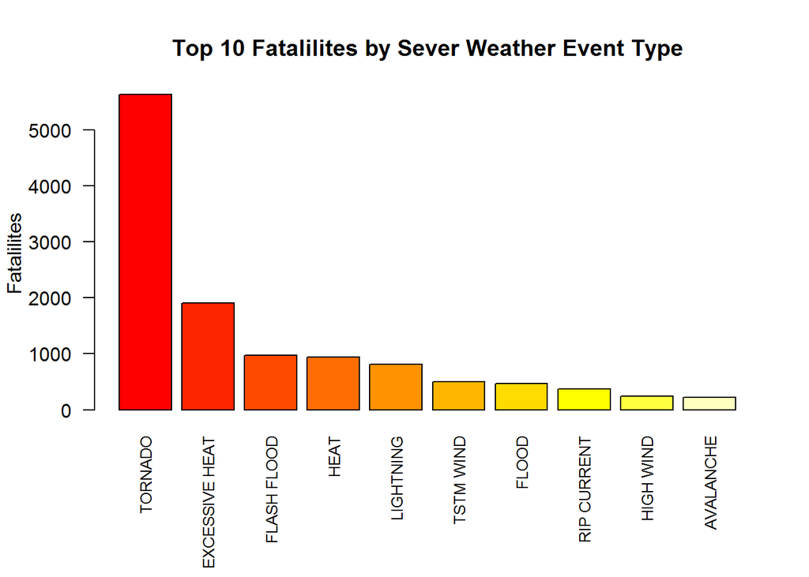

```r
par(mar= c(7, 4, 4, 2) + 0.1)
barplot(height = EvtypeFatal$FATALITIES[1:10], names.arg = EvtypeFatal$EVTYPE[1:10], las = 2, cex.names= 0.8, col = heat.colors (10), main = "Top 10 Fatalilites by Sever Weather Event Type", ylab = "Fatalilites")
```

Below shows us the most injury causing types of sever weather events.

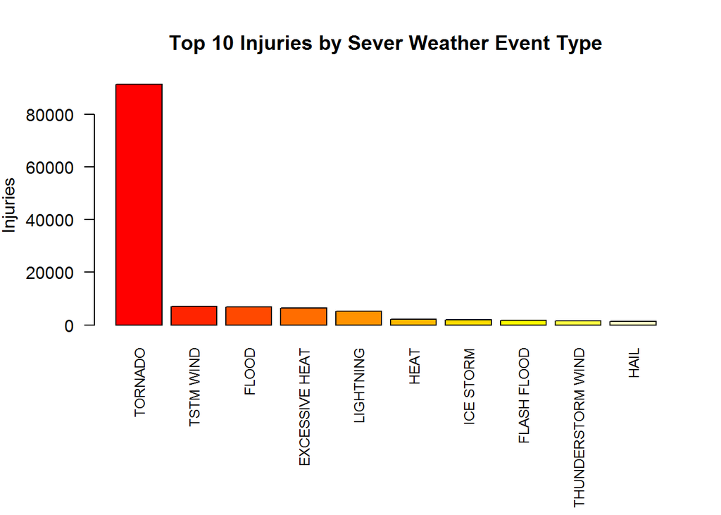

```r
par(mar= c(9, 4.5, 4, 2) + 0.1)
barplot(height = EvtypeInjuries$INJURIES[1:10], names.arg = EvtypeInjuries$EVTYPE[1:10], las = 2, cex.names= 0.8, col = heat.colors (10), main = "Top 10 Injuries by Sever Weather Event Type", ylab="" )
mtext("Injuries", side=2, line=3.7)
```

As we can see from the above two graphs Tornado is by far the most dangerous type of sever weather event for both fatalities and injuries.

### Type of weather event with the greatest economic consequences

In graph below we can see Total Damage by type of weather event in billions $USD where total Damage is the combination of both property + crop damage.

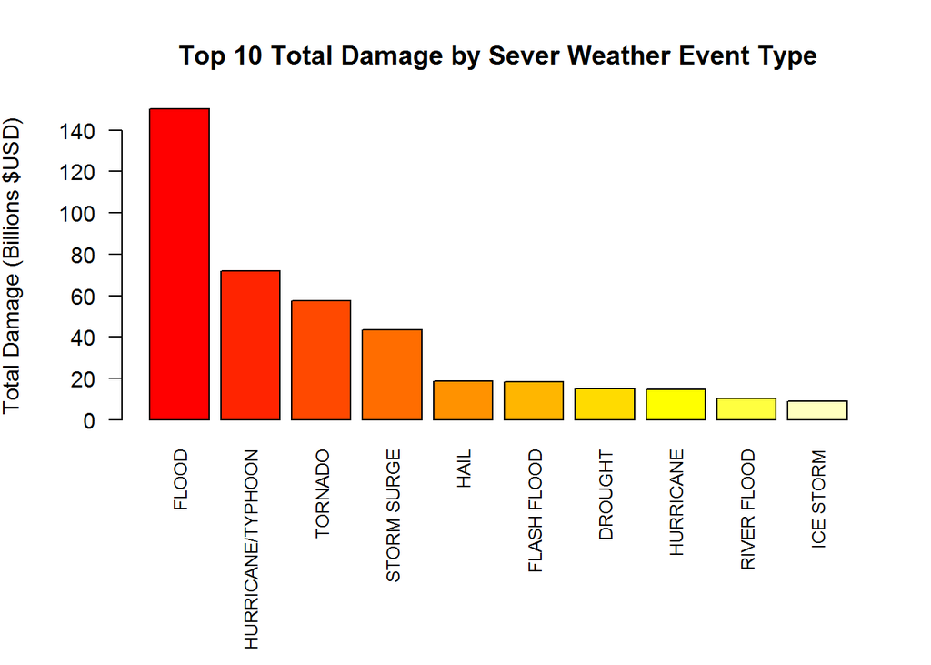

```r
par(mar= c(9, 4.5, 4, 2) + 0.1)
barplot(height = DamageEst$DamageBillions[1:10], names.arg = DamageEst$EVTYPE[1:10], las = 2, cex.names= 0.8, col = heat.colors (10), main = "Top 10 Total Damage by Sever Weather Event Type", ylab="" )
mtext("Total Damage (Billions $USD)", side=2, line=3.7)
```

The above graph shows the most damaging type of sever weather event is Flooding followed by Hurricane/Typhoon and Tornado.

## Conclusions

From the above graphs it can be seen that Tornado is the most harmful type of sever weather event while Flooding is the has the greatest economic consequences in terms of property and crop damage.